# Part I - Loan Data from Propser Analysis

## Introduction

> Prosper is a company that offers a variety of resources people can use to try and improve their financial health, regardless of their financial situation. Since 2005, Prosper has facilitated more than 22 billion dollars in loans to more than 1,340,000 people. In this project, we're going to be analyzing 113, 937 of those loans. Each of these loans consist of 81 variables, including loan amount, borrower rate (or interest rate), current loan status, borrower income, and many others. This dataset can be further categorized into two main categories as stated below:
> - **Borrower information:** Basic attributes of the borrowers such as annual income, condition of employment, interest rate, loan status, etc.
> - **Loan performance information:** Metrics evaluating the risk associated with the loans such as Prosper score and bank card utilization, etc.

## Preliminary Wrangling

```python
# import all packages and set plots to be embedded inline
import numpy as np
import pandas as pd
import matplotlib.pyplot as plt
import seaborn as sns

%matplotlib inline
```

> Now that we've imported all the packages we'll be needing for this analysis, the next step is to upload the dataset we are going to be analyzing.

```python
# load in dataset into a pandas dataframe
df = pd.read_csv('prosperLoanData.csv')
df.head()
```

|  | ListingKey | ListingNumber | ListingCreationDate | CreditGrade | Term | LoanStatus | ClosedDate | BorrowerAPR | BorrowerRate | LenderYield | ... | LP_ServiceFees | LP_CollectionFees | LP_GrossPrincipalLoss | LP_NetPrincipalLoss | LP_NonPrincipalRecoverypayments | PercentFunded | Recommendations | InvestmentFromFriendsCount | InvestmentFromFriendsAmount | Investors |
| --- | --- | --- | --- | --- | --- | --- | --- | --- | --- | --- | --- | --- | --- | --- | --- | --- | --- | --- | --- | --- | --- |
| 0 | 1021339766868145413AB3B | 193129 | 2007-08-26 19:09:29.263000000 | C | 36 | Completed | 2009-08-14 00:00:00 | 0.16516 | 0.1580 | 0.1380 | ... | -133.18 | 0.0 | 0.0 | 0.0 | 0.0 | 1.0 | 0 | 0 | 0.0 | 258 |
| 1 | 10273602499503308B223C1 | 1209647 | 2014-02-27 08:28:07.900000000 | NaN | 36 | Current | NaN | 0.12016 | 0.0920 | 0.0820 | ... | 0.00 | 0.0 | 0.0 | 0.0 | 0.0 | 1.0 | 0 | 0 | 0.0 | 1 |
| 2 | 0EE9337825851032864889A | 81716 | 2007-01-05 15:00:47.090000000 | HR | 36 | Completed | 2009-12-17 00:00:00 | 0.28269 | 0.2750 | 0.2400 | ... | -24.20 | 0.0 | 0.0 | 0.0 | 0.0 | 1.0 | 0 | 0 | 0.0 | 41 |
| 3 | 0EF5356002482715299901A | 658116 | 2012-10-22 11:02:35.010000000 | NaN | 36 | Current | NaN | 0.12528 | 0.0974 | 0.0874 | ... | -108.01 | 0.0 | 0.0 | 0.0 | 0.0 | 1.0 | 0 | 0 | 0.0 | 158 |
| 4 | 0F023589499656230C5E3E2 | 909464 | 2013-09-14 18:38:39.097000000 | NaN | 36 | Current | NaN | 0.24614 | 0.2085 | 0.1985 | ... | -60.27 | 0.0 | 0.0 | 0.0 | 0.0 | 1.0 | 0 | 0 | 0.0 | 20 |

5 rows × 81 columns

```python
# Overview of data shape and composition
df.shape
```

```
(113937, 81)
```

```python
#statistical summary of the dataset
df.describe()
```

|  | ListingNumber | Term | BorrowerAPR | BorrowerRate | LenderYield | EstimatedEffectiveYield | EstimatedLoss | EstimatedReturn | ProsperRating (numeric) | ProsperScore | ... | LP_ServiceFees | LP_CollectionFees | LP_GrossPrincipalLoss | LP_NetPrincipalLoss | LP_NonPrincipalRecoverypayments | PercentFunded | Recommendations | InvestmentFromFriendsCount | InvestmentFromFriendsAmount | Investors |
| --- | --- | --- | --- | --- | --- | --- | --- | --- | --- | --- | --- | --- | --- | --- | --- | --- | --- | --- | --- | --- | --- |
| count | 1.139370e+05 | 113937.000000 | 113912.000000 | 113937.000000 | 113937.000000 | 84853.000000 | 84853.000000 | 84853.000000 | 84853.000000 | 84853.000000 | ... | 113937.000000 | 113937.000000 | 113937.000000 | 113937.000000 | 113937.000000 | 113937.000000 | 113937.000000 | 113937.000000 | 113937.000000 | 113937.000000 |
| mean | 6.278857e+05 | 40.830248 | 0.218828 | 0.192764 | 0.182701 | 0.168661 | 0.080306 | 0.096068 | 4.072243 | 5.950067 | ... | -54.725641 | -14.242698 | 700.446342 | 681.420499 | 25.142686 | 0.998584 | 0.048027 | 0.023460 | 16.550751 | 80.475228 |
| std | 3.280762e+05 | 10.436212 | 0.080364 | 0.074818 | 0.074516 | 0.068467 | 0.046764 | 0.030403 | 1.673227 | 2.376501 | ... | 60.675425 | 109.232758 | 2388.513831 | 2357.167068 | 275.657937 | 0.017919 | 0.332353 | 0.232412 | 294.545422 | 103.239020 |
| min | 4.000000e+00 | 12.000000 | 0.006530 | 0.000000 | -0.010000 | -0.182700 | 0.004900 | -0.182700 | 1.000000 | 1.000000 | ... | -664.870000 | -9274.750000 | -94.200000 | -954.550000 | 0.000000 | 0.700000 | 0.000000 | 0.000000 | 0.000000 | 1.000000 |
| 25% | 4.009190e+05 | 36.000000 | 0.156290 | 0.134000 | 0.124200 | 0.115670 | 0.042400 | 0.074080 | 3.000000 | 4.000000 | ... | -73.180000 | 0.000000 | 0.000000 | 0.000000 | 0.000000 | 1.000000 | 0.000000 | 0.000000 | 0.000000 | 2.000000 |
| 50% | 6.005540e+05 | 36.000000 | 0.209760 | 0.184000 | 0.173000 | 0.161500 | 0.072400 | 0.091700 | 4.000000 | 6.000000 | ... | -34.440000 | 0.000000 | 0.000000 | 0.000000 | 0.000000 | 1.000000 | 0.000000 | 0.000000 | 0.000000 | 44.000000 |
| 75% | 8.926340e+05 | 36.000000 | 0.283810 | 0.250000 | 0.240000 | 0.224300 | 0.112000 | 0.116600 | 5.000000 | 8.000000 | ... | -13.920000 | 0.000000 | 0.000000 | 0.000000 | 0.000000 | 1.000000 | 0.000000 | 0.000000 | 0.000000 | 115.000000 |
| max | 1.255725e+06 | 60.000000 | 0.512290 | 0.497500 | 0.492500 | 0.319900 | 0.366000 | 0.283700 | 7.000000 | 11.000000 | ... | 32.060000 | 0.000000 | 25000.000000 | 25000.000000 | 21117.900000 | 1.012500 | 39.000000 | 33.000000 | 25000.000000 | 1189.000000 |

8 rows × 61 columns

### What is the structure of your dataset?

> There are 113,937 loans in the dataset with 81 features. Most variables are numeric and categorical in nature.

> As earlier stated, the dataset features can be split into two main categories:
> - Borrower information
> - Loan performance information

### What is/are the main feature(s) of interest in your dataset?

> From an investor's point of view, it will be interesting to figure out which borrower features are the best for predicting the highest rate of return.

> Secondly, we can look at how closely the estimated loan performance match the actual loan performance.

### What features in the dataset do you think will help support your investigation into your feature(s) of interest?

> There are many features in this datset to explore, however, it will be interesting to see the borrowers features that will have more significant influence on the performance of the loan. On that note, the following features will help in supporting the investigation of these features of interest.
> - **IncomeRange** - The income range of the borrower at the time the listing was created.
> - **DebToIncomeRatio** - The debt to income ratio of the borrower at the time the credit profile was pulled. This value is Null if the debt to income ratio is not available. This value is capped at 10.01 (any debt to income ratio larger than 1000% will be returned as 1001%).
> - **CreditGrade** - The Credit rating that was assigned at the time the listing went live. Applicable for listings pre-2009 period and will only be populated for those listings.
> - **ProsperRating (Alpha)** - The Prosper Rating assigned at the time the listing was created between AA - HR. Applicable for loans originated after July 2009.

> The performance of the loan can be determined by the following features:
> - **EstimatedReturn** - The estimated return assigned to the listing at the time it was created. Estimated return is the difference between the Estimated Effective Yield and the Estimated Loss Rate. Applicable for loans originated after July 2009. This is on an annual percentage rate (APR).
> - **ActualReturn** - To see how well our note performed vs the Estimated Returns, we will derive this feature based on how Prosper calculates their Annualized Net Returns.

## Univariate Exploration

### Estimated Return

> Let's start by getting a closer look at our feature of intrests beginning with the estimated returns.

```python
df.EstimatedReturn.describe()
```

```
count    84853.000000
mean         0.096068
std          0.030403
min         -0.182700
25%          0.074080
50%          0.091700
75%          0.116600
max          0.283700
Name: EstimatedReturn, dtype: float64
```

> It appears we have quite a few empty cells since the total number of rows is over 100,000. The range of estimated returns is -18% to 28%. From the quartile distribution I expect to see a possible right skewed distribution plot. Let's drop the null rows and proceed with a histogram plot.

```python
# drop null rows without an estimated return
df.EstimatedReturn.dropna(axis = 0, inplace = True)
```

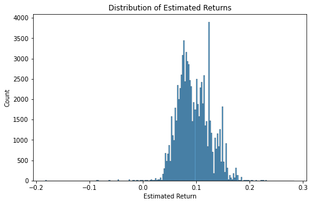

```python
# histogram plot
plt.figure(figsize = [8,5])
sns.histplot(df.EstimatedReturn, kde = False, bins = 200)
plt.xlabel('Estimated Return')
plt.ylabel('Count')
plt.title('Distribution of Estimated Returns');
```

> It appears most of our loans have an estimated return between 0% and 20%, let's zoom in on this distribution.

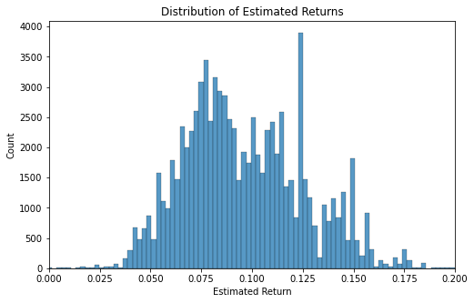

```python
# zoom in on histogram
plt.figure(figsize = [8,5])
sns.histplot(df.EstimatedReturn, kde = False, bins = 200)
plt.xlim(0, .2)
plt.xlabel('Estimated Return')
plt.ylabel('Count')
plt.title('Distribution of Estimated Returns');
```

> Our quartile analysis appears to be correct as the distribution is right skewed. It also looks like there are some peaks in some standard values such as 5%, 7.5%, 12.5%, and 15%. Most curiously the largest bin falls right around 12.5%. Let's try to calculate the actual returns and see how they compare to the estimated returns.

### Actual Return

> This section appears to be quite nuanced and required a bit of feature engineering. Let's try to calculate the actual returns by using the remaining loan performance (LP) variables.

> From [Prosper's FAQs](https://prosper.zendesk.com/hc/en-us/articles/360001288366-Frequently-Asked-Questions-about-Historical-Returns) we calculated Historical Return for loans originated through Prsoper as follows: ...(a) the sum of the Interest Paid, plus Late Fees, minus Servicing Fees, minus Collection Fees, in each case on active loans, plus Net Recoveries on charged-off or defaulted loans, plus Net Debt Sale Proceeds on sold loans, minus Gross Principal Losses; divided by (b) the sum of the Principal Balances Outstanding on active loans at the end of each day since origination. We then annualize the result to get the “Historical Return” for the Group.*

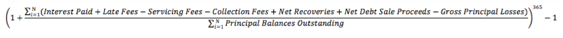

> To simplify our calculation for exploratory purposes, we will only divide by the original loan amount. We will run into other categorical issues if we try to determine the current rate of return for current loans vs completed loans etc. We may revisit this section to refine our actual returns feature.

> Actual Returns = 1 + {Customer Payments - Original Loan Amount - (Service Fees + Collection Fees + Net Principal Losses)}/{Original Loan Amount}

```python
# simplified actual return formula
df['ActualReturns'] = df.LP_CustomerPayments - df.LoanOriginalAmount - (df.LP_ServiceFees + df.LP_CollectionFees + df.LP_NetPrincipalLoss)
df['ActualReturns'] = 1 + (df.ActualReturns / df.LoanOriginalAmount)
```

```python
df.ActualReturns.describe()
```

```
count    113937.000000
mean          0.531620
std           0.621164
min          -1.000650
25%           0.074989
50%           0.415864
75%           1.119834
max           2.602880
Name: ActualReturns, dtype: float64
```

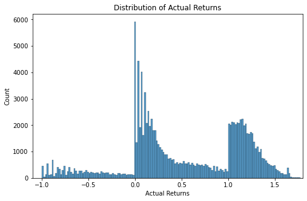

```python
# plot distribution
plt.figure(figsize = [8,5])
sns.histplot(df.ActualReturns, kde = False, bins = 200)
plt.xlim(-1.1, 1.8)
plt.xlabel('Actual Returns')
plt.ylabel('Count')
plt.title('Distribution of Actual Returns');
```

> It's interesting to see the wide range of values for actual returns. There are some loans where it appears that the borrower never made a payment which gives us the minimum of losing 100% of the investment. On the other end of the spectrum, it looks like most loans drop off after about 170% of the original loan amount.

> As earlier mentioned, to simplify the visualization, this calculation is not annualized based on the length of the loans, so this is not quite an apples to apples comparison with the estimated return which is annualized.

> Since there appears to be differnt modes to the distribution, let's see how the actual returns differ by the loan status:

[figure not shown]

```python
# multiplot for loan status

variables = ['Current', 'Completed', 'Chargedoff', 'Defaulted']

plt.figure(figsize = [16, 10])

# loop through variables list
for i in range(len(variables)):
    plt.subplot(2, 2, i+1)

    sns.histplot(df.query('LoanStatus == "{}"'.format(variables[i])).ActualReturns,
                 kde = False, bins = 200)

    plt.xlabel('Actual Returns')
    plt.ylabel('Count')
    plt.title(variables[i])

plt.subplot(2, 2, 2)
plt.xlim(.9, 1.8)

plt.suptitle('Distribution of Estimated Returns by Loan Status');
```

> For the current loans, there appears to be a large number of loans that have an actual return value of 0. This could mean that "Current" also takes into account all the loans that have not been fully funded yet. We would have to explore this further to extract loans that have been fully funded.

> Since our actual returns feature is not annualized, we see that for the loan terms of 3-5 years, an investor could see a total return of 170%.

> For loans that have defaulted or have been chargedoff, it makes sense that a majority of them show negative returns up to 100%. Meaning that the borrower could have never made a payment or the service/collection fees resulted in the investor losing their entire principal. Of course this is the worst case scenario. It's reassuring to see that this occurs in a minority of the loans, however it is nonzero and has a significant impact on an investors portfolio if they are diversified over several notes.

### Prosper Credit Grade

Now that we have a high level overview of what the returns on the platform look like, let's see if there is a similar or distribution for the borrower's prosper/credit grade.

```python
df['ProsperRating (Alpha)'].describe()
```

```
count     84853
unique        7
top           C
freq      18345
Name: ProsperRating (Alpha), dtype: object
```

```python
df['ProsperRating (Alpha)'].value_counts()
```

```
C     18345
B     15581
A     14551
D     14274
E      9795
HR     6935
AA     5372
Name: ProsperRating (Alpha), dtype: int64
```

```python
df['CreditGrade'].describe()
```

```
count     28953
unique        8
top           C
freq       5649
Name: CreditGrade, dtype: object
```

```python
df['CreditGrade'].value_counts()
```

```
C     5649
D     5153
B     4389
AA    3509
HR    3508
A     3315
E     3289
NC     141
Name: CreditGrade, dtype: int64
```

```python
# replace NC with HR
df['CreditGrade'].replace(['NC', 'HR'], 'E', inplace = True)

# fill NA with empty strings
df['ProsperRating (Alpha)'].fillna("", inplace = True)
df['CreditGrade'].fillna("", inplace = True)

# combine credit ratings
df['ProsperRatingCombined'] = df['ProsperRating (Alpha)'] + df['CreditGrade']

# drop rows with no credit ratings
df = df.query(' ProsperRatingCombined != ""')

# check values
df['ProsperRatingCombined'].value_counts()
```

```
C     23994
B     19970
D     19427
A     17866
E     16733
AA     8881
HR     6935
Name: ProsperRatingCombined, dtype: int64
```

> We could have a potential issue with two 'A' grades combining to make an 'AA' grade. Let's double check the number of values before and after to make sure we didn't erroneously create 'AA' grades.

```python
# Check that the number of A and AA ratings the same before and after combining the columns?
(df['ProsperRatingCombined'] == 'A').sum() == (df.CreditGrade == 'A').sum() + (df['ProsperRating (Alpha)'] == 'A').sum() and \
(df['ProsperRatingCombined'] == 'AA').sum() == (df.CreditGrade == 'AA').sum() + (df['ProsperRating (Alpha)'] == 'AA').sum()
```

```
True
```

> It looks good, we didn't introduce any erroneous data since there were no rows with an 'A' rating for both their Credit Grade and Prosper Rating.

> Now let's plot our visualization!

```python
# convert string to ordinal category type
ordinal_rating = ['AA', 'A', 'B', 'C', 'D', 'E']
ordered_var = pd.api.types.CategoricalDtype(ordered = True, categories = ordinal_rating)
df['ProsperRatingCombined'] = df['ProsperRatingCombined'].astype(ordered_var)
```

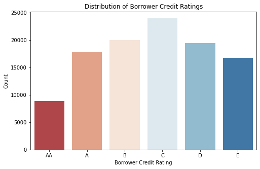

```python
plt.figure(figsize = [8, 5])
sns.countplot(data = df, x = 'ProsperRatingCombined', palette = "RdBu")
plt.xlabel('Borrower Credit Rating')
plt.ylabel('Count')
plt.title('Distribution of Borrower Credit Ratings');
```

> This could mean that for a particular credit rating we have a range of possible estimated returns. We will look into this in our bivariate visualizations.

### Income Range

> To continue on further exploration, let's look at a couple of features for borrowers to be assigned these Credit Ratings. We will do this by taking a look at the income ranges.

```python
df.IncomeRange.value_counts()
```

```
$25,000-49,999    32152
$50,000-74,999    31005
$100,000+         17321
$75,000-99,999    16899
Not displayed      7741
$1-24,999          7261
Not employed        806
$0                  621
Name: IncomeRange, dtype: int64
```

```python
# create ordinal categories for income
ordinal_rating = ['$100,000+', '$75,000-99,999', '$50,000-74,999', '$25,000-49,999', '$1-24,999', '$0']
ordered_var = pd.api.types.CategoricalDtype(ordered = True, categories = ordinal_rating)
df['IncomeRange'] = df['IncomeRange'].astype(ordered_var)
```

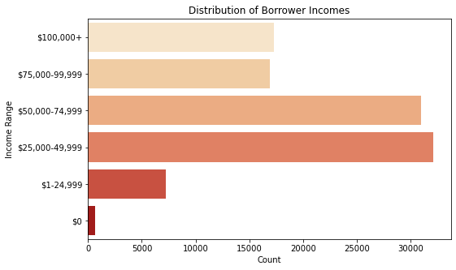

```python
# bar chart
plt.figure(figsize = [8, 5])
sns.countplot(data = df, y = 'IncomeRange', palette = "OrRd")
plt.ylabel('Income Range')
plt.xlabel('Count')
plt.title('Distribution of Borrower Incomes');
```

> From the above visualization, we can see that the number of borrowers for the 25k-49k range is almost the same as the 50k-74k range. The amount of borrowers in the 75k-100k range is the same as all borrowers that have an income of over 100k

### Debt to Income Ratio

> We should note that an income is only part of the picture. Let's see what the borrower's Debt to Income Ratio is like. It might be that a creditor wants to make sure you're not overleveraged in the event you have a loss of income and are unable to repay all of your debts.

```python
df.DebtToIncomeRatio.describe()
```

```
count    105263.000000
mean          0.275976
std           0.551811
min           0.000000
25%           0.140000
50%           0.220000
75%           0.320000
max          10.010000
Name: DebtToIncomeRatio, dtype: float64
```

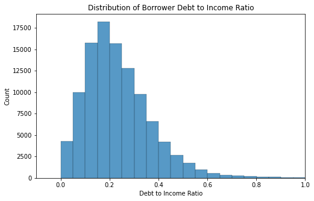

```python
# distribution plot
plt.figure(figsize = [8,5])
sns.histplot(df.DebtToIncomeRatio, kde = False, bins = 200)
plt.xlim(-.1, 1)
plt.xlabel('Debt to Income Ratio')
plt.ylabel('Count')
plt.title('Distribution of Borrower Debt to Income Ratio');
```

> It appears that most borrowers who apply for a loan have a debt to income ratio around 20%.

### Discuss the distribution(s) of your variable(s) of interest. Were there any unusual points? Did you need to perform any transformations?

> To summarize our variables of interest, we looked at income, debt to income ratios, credit ratings, estimated returns and actual returns for the data set.

> We saw relatively normal distributions for income, debt to income, credit ratings, and estimated returns. However, trying to calculate the real time actual returns proved to be difficult. This may require further analysis if we are going to try an answer particulare questions about the dataset.

### Of the features you investigated, were there any unusual distributions? Did you perform any operations on the data to tidy, adjust, or change the form of the data? If so, why did you do this?

> While carrying out the analysis, it was observed that from our simplified actual returns fomula, the values returned varied significantly between different loan statuses.

## Bivariate Exploration

### Quantitative vs. Quantitative

> To start this bivariate exploration, we need to look at the pair correlation between numeric features of interest.

```python
# numeric and categorical variables
numeric_vars = ['DebtToIncomeRatio', 'ActualReturns', 'EstimatedReturn']
categoric_vars = ['IncomeRange', 'ProsperRatingCombined']
```

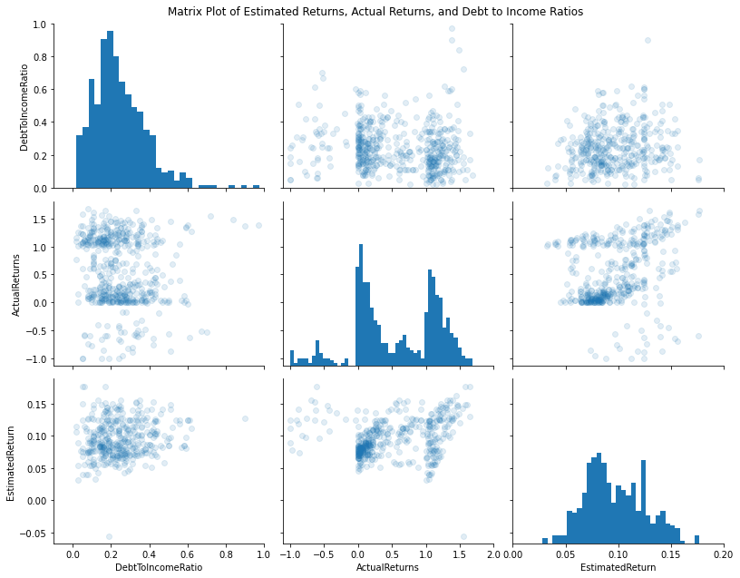

```python
# plot matrix with 0.5% of data points
samples = np.random.choice(df.shape[0], int(df.shape[0]*.005), replace = False)
df_samp = df.loc[samples,:]

# pair grid
g = sns.PairGrid(data = df_samp, vars = numeric_vars, height = 3, aspect = 1.25)
g = g.map_diag(plt.hist, bins = 50)
g.map_offdiag(plt.scatter, alpha = 1/8)

# set axis limits
g.axes[0,0].set_ylim(0,1)
g.axes[0,0].set_xlim(-.1,1)
g.axes[0,1].set_xlim(-1.1,2)
g.axes[0,2].set_xlim(0,.2)

g.fig.suptitle('Matrix Plot of Estimated Returns, Actual Returns, and Debt to Income Ratios')
g.fig.subplots_adjust(top = .95);
```

> We have a good understanding of the range of values we can expect from our univariate exploration. By limiting the axis values, we can prevent outliers from skewing the plot. Otherwise, most of the points will appear to be grouped in a vertical line.

> Surprisingly, there doesn't seem to be any correlation between the estimated returns and the actual returns we calculated. We may have to investigate further by querying select categories of loan status.

> There doesn't seem to be any correlation between any of the other numeric variables either.

> You may intuitively expect borrowers with a high debt to income ratio to be riskier and thus have a lower rate of return - but that doesn't appear to be the case.

**Let's take a look at how a borrower's income range and credit rating relates to the investor's estimated returns.**

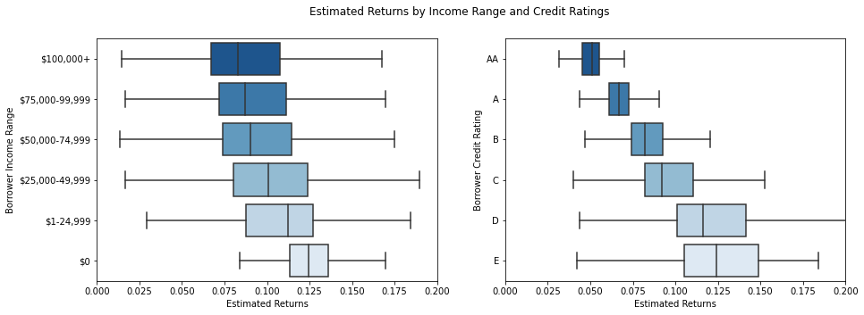

```python
# boxplots
plt.figure(figsize = [15, 5])

plt.subplot(1, 2, 1)
base_color = sns.color_palette()[0]
sns.boxplot(data = df, y = 'IncomeRange', x = 'EstimatedReturn', palette = "Blues_r", showfliers = False)
plt.xlim(0,.2)
plt.ylabel('Borrower Income Range')
plt.xlabel('Estimated Returns')

plt.subplot(1, 2, 2)
base_color = sns.color_palette()[0]
sns.boxplot(data = df, y = 'ProsperRatingCombined', x = 'EstimatedReturn', palette = "Blues_r", showfliers = False)
plt.xlim(0,.2)
plt.ylabel('Borrower Credit Rating')
plt.xlabel('Estimated Returns')

plt.suptitle('Estimated Returns by Income Range and Credit Ratings');
```

> The next step for this analysis is to go ahead and plot the actual returns.

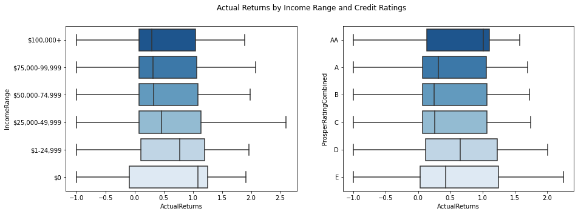

```python
# boxplots
plt.figure(figsize = [15, 5])

plt.subplot(1, 2, 1)
base_color = sns.color_palette()[0]
sns.boxplot(data = df, y = 'IncomeRange', x = 'ActualReturns', palette = "Blues_r", showfliers = False)

plt.subplot(1, 2, 2)
base_color = sns.color_palette()[0]
sns.boxplot(data = df, y = 'ProsperRatingCombined', x = 'ActualReturns', palette = "Blues_r", showfliers = False);

plt.suptitle('Actual Returns by Income Range and Credit Ratings');
```

> From the above, we can see that it seems that investing in borrowers with no reported income and highest credit ratings will result in the highest returns.

**Let's plot the credit score along with the income range.**

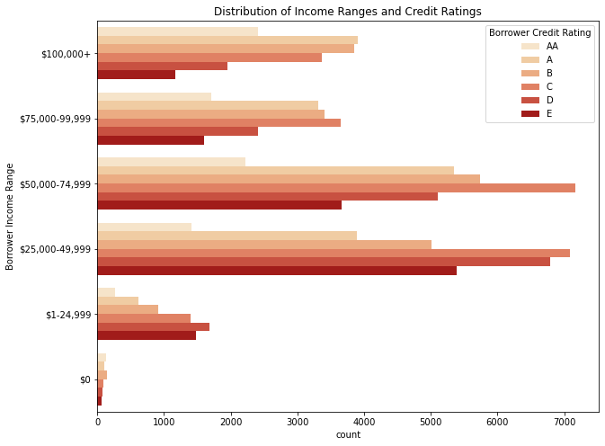

```python
# clustered bar chart
plt.figure(figsize = [10,8])

ax = sns.countplot(data = df, y = 'IncomeRange', hue = 'ProsperRatingCombined',
                   palette = 'OrRd')

ax.legend(title = 'Borrower Credit Rating')
plt.title('Distribution of Income Ranges and Credit Ratings')
plt.ylabel('Borrower Income Range');
```

> From the visualization above, we can see that there is a trend where the higher incomes correlate to a higher credit rating qualifying the borrower for the best (lowest) interest rates. This means that having an income of 75k doesn't guarantee the best credit ratings. There may be other factors that can influence one's credit rating. We can also see that in those in the income range of 0 also have a high amount of "AA" loans relative to those in the range of 1-25k. This also shows that borrowers in the 0 range may have other significant assets or credible history with Prosper for them to receive the highest credit rating without any income.

### Talk about some of the relationships you observed in this part of the investigation. How did the feature(s) of interest vary with other features in the dataset?

> There wasn't a lot of variations. It was surprising to see that there was no correlation between debt to income ratios, estimated returns, and actual returns.

## Multivariate Exploration

> In this section, the main point of exploration is the relationship between income ranges, credit scores, and estimated returns.

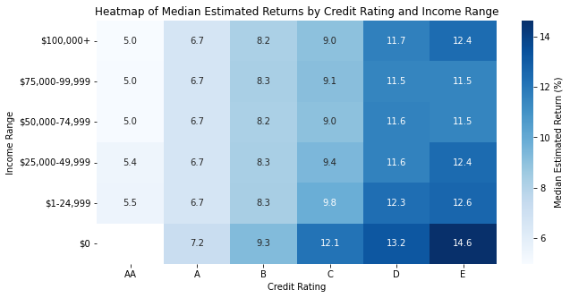

```python
# create a heat map of average estimated returnsb
plt.figure(figsize = [10,5])

cat_med = df.groupby(['ProsperRatingCombined', 'IncomeRange']).median()['EstimatedReturn']*100
cat_med = cat_med.reset_index(name = 'EstimatedReturnMedian')
cat_med = cat_med.pivot(index = 'IncomeRange', columns = 'ProsperRatingCombined', values = 'EstimatedReturnMedian')

sns.heatmap(cat_med, annot = True, fmt = '.1f', cmap = "Blues", cbar_kws = {'label' : 'Median Estimated Return (%)'})
plt.xlabel('Credit Rating')
plt.ylabel('Income Range')
plt.title('Heatmap of Median Estimated Returns by Credit Rating and Income Range');
```

> From the above heatmap representation, we can see the trend of lower credit ratings, and lower incomes equating to higher returns. One thing to note here is how the income range does not play a huge factor on estimated returns by credit rating category.

> Since we know that credit ratings are a better indicator of estimated returns, let's see if the status of a loan will allow us to see a correlation between our estimated returns and actual returns.

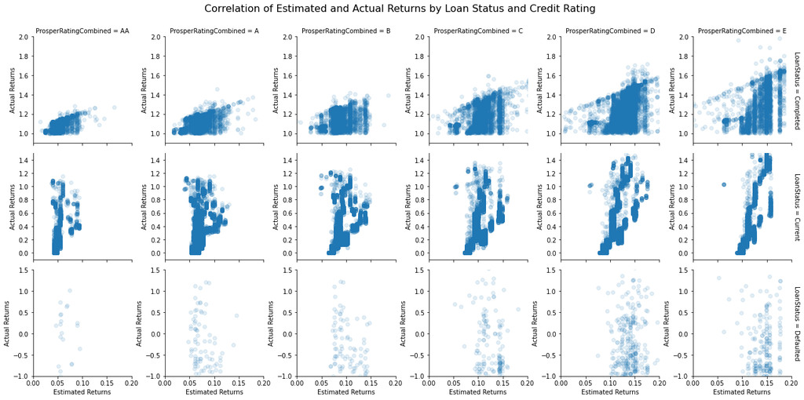

```python
# create scatter plot across credit ratings and loan status
g = sns.FacetGrid(data = df, col = 'ProsperRatingCombined', row_order = ['Completed', 'Current', 'Defaulted'],
                  row = 'LoanStatus', margin_titles = True, xlim = (0,.2), sharey = False)
g.map(plt.scatter, 'EstimatedReturn', 'ActualReturns', alpha = 1/8)

# set different y axes for different loan statuses
for i, ax in enumerate(g.axes.flat):
    if i < 6:
        ax.set_ylim(.9, 2)
    elif i < 12:
        ax.set_ylim(-.1, 1.5)
    else:
        ax.set_ylim(-1, 1.5)

g.set(xlabel = 'Estimated Returns', ylabel = 'Actual Returns')

g.fig.suptitle('Correlation of Estimated and Actual Returns by Loan Status and Credit Rating', size = 16)
g.fig.subplots_adjust(top = .9);
```

### Talk about some of the relationships you observed in this part of the investigation. Were there features that strengthened each other in terms of looking at your feature(s) of interest?

> I simplified the plot a bit by only looking at three loan statuses: Completed, Current, and Defaulted.

> For loans that are defaulted, there doesn't appear to be any correlation between the predicted estimated return and the actual return of the loan.

> For loans that are current, there appears to be a linear relationship between the estimated and actual returns! Recall that during our bivariate exploration we were unable to see the trend as all of the loan status were lumped together.

> For loans that are completed, we can se there is a clear linear relationship with estimated returns and actual returns. However, it also appears this linear line is shaded as well. This means that no matter what the estimated return for the loan was, there is a chance the loan always returns the full balance. This may occur if a borrower received the loan and quickly paid it off in a couple of months, minimizing the amount of interest paid.

## Conclusions

> This was a large dataset and a lot more analysis can be further done to dig deeper into revealing the actual insight of the data. It was interesting to analyze from an investors perspective. Seeing all the features and variables that could potentially influence loan repayment and bring high return.